# Homework 1 - Data Science 3 - Exercise 1

Oscar Leal - ID: 1903161

3/3/2020

## 1. Tree ensemble models (7 points)

In this problem you are going to work with the OJ dataset from the ISLR package. This dataset records purchases of two types of orange juices and presents customer and product characteristics as features. The goal is to predict which of the juices is chosen in a given purchase situation. See ?ISLR::OJ for a description of the variables.

```r
data <- data.table(OJ)
skim(data)
```

Data summary

| Name | data |
| --- | --- |
| Number of rows | 1070 |
| Number of columns | 18 |
| _______________________ |  |
| Column type frequency: |  |
| factor | 2 |
| numeric | 16 |
| ________________________ |  |
| Group variables | None |

**Variable type: factor**

| skim_variable | n_missing | complete_rate | ordered | n_unique | top_counts |
| --- | --- | --- | --- | --- | --- |
| Purchase | 0 | 1 | FALSE | 2 | CH: 653, MM: 417 |
| Store7 | 0 | 1 | FALSE | 2 | No: 714, Yes: 356 |

**Variable type: numeric**

| skim_variable | n_missing | complete_rate | mean | sd | p0 | p25 | p50 | p75 | p100 | hist |
| --- | --- | --- | --- | --- | --- | --- | --- | --- | --- | --- |
| WeekofPurchase | 0 | 1 | 254.38 | 15.56 | 227.00 | 240.00 | 257.00 | 268.00 | 278.00 | ▆▅▅▇▇ |
| StoreID | 0 | 1 | 3.96 | 2.31 | 1.00 | 2.00 | 3.00 | 7.00 | 7.00 | ▇▅▃▁▇ |
| PriceCH | 0 | 1 | 1.87 | 0.10 | 1.69 | 1.79 | 1.86 | 1.99 | 2.09 | ▅▂▇▆▁ |
| PriceMM | 0 | 1 | 2.09 | 0.13 | 1.69 | 1.99 | 2.09 | 2.18 | 2.29 | ▂▁▃▇▆ |
| DiscCH | 0 | 1 | 0.05 | 0.12 | 0.00 | 0.00 | 0.00 | 0.00 | 0.50 | ▇▁▁▁▁ |
| DiscMM | 0 | 1 | 0.12 | 0.21 | 0.00 | 0.00 | 0.00 | 0.23 | 0.80 | ▇▁▂▁▁ |
| SpecialCH | 0 | 1 | 0.15 | 0.35 | 0.00 | 0.00 | 0.00 | 0.00 | 1.00 | ▇▁▁▁▂ |
| SpecialMM | 0 | 1 | 0.16 | 0.37 | 0.00 | 0.00 | 0.00 | 0.00 | 1.00 | ▇▁▁▁▂ |
| LoyalCH | 0 | 1 | 0.57 | 0.31 | 0.00 | 0.33 | 0.60 | 0.85 | 1.00 | ▅▃▆▆▇ |
| SalePriceMM | 0 | 1 | 1.96 | 0.25 | 1.19 | 1.69 | 2.09 | 2.13 | 2.29 | ▁▂▂▂▇ |
| SalePriceCH | 0 | 1 | 1.82 | 0.14 | 1.39 | 1.75 | 1.86 | 1.89 | 2.09 | ▂▁▇▇▅ |
| PriceDiff | 0 | 1 | 0.15 | 0.27 | -0.67 | 0.00 | 0.23 | 0.32 | 0.64 | ▁▂▃▇▂ |
| PctDiscMM | 0 | 1 | 0.06 | 0.10 | 0.00 | 0.00 | 0.00 | 0.11 | 0.40 | ▇▁▂▁▁ |
| PctDiscCH | 0 | 1 | 0.03 | 0.06 | 0.00 | 0.00 | 0.00 | 0.00 | 0.25 | ▇▁▁▁▁ |
| ListPriceDiff | 0 | 1 | 0.22 | 0.11 | 0.00 | 0.14 | 0.24 | 0.30 | 0.44 | ▂▃▆▇▁ |
| STORE | 0 | 1 | 1.63 | 1.43 | 0.00 | 0.00 | 2.00 | 3.00 | 4.00 | ▇▃▅▅▃ |

```r
summary(data)
```

```
##  Purchase WeekofPurchase     StoreID        PriceCH         PriceMM
##  CH:653   Min.   :227.0   Min.   :1.00   Min.   :1.690   Min.   :1.690
##  MM:417   1st Qu.:240.0   1st Qu.:2.00   1st Qu.:1.790   1st Qu.:1.990
##           Median :257.0   Median :3.00   Median :1.860   Median :2.090
##           Mean   :254.4   Mean   :3.96   Mean   :1.867   Mean   :2.085
##           3rd Qu.:268.0   3rd Qu.:7.00   3rd Qu.:1.990   3rd Qu.:2.180
##           Max.   :278.0   Max.   :7.00   Max.   :2.090   Max.   :2.290
##      DiscCH            DiscMM         SpecialCH        SpecialMM
##  Min.   :0.00000   Min.   :0.0000   Min.   :0.0000   Min.   :0.0000
##  1st Qu.:0.00000   1st Qu.:0.0000   1st Qu.:0.0000   1st Qu.:0.0000
##  Median :0.00000   Median :0.0000   Median :0.0000   Median :0.0000
##  Mean   :0.05186   Mean   :0.1234   Mean   :0.1477   Mean   :0.1617
##  3rd Qu.:0.00000   3rd Qu.:0.2300   3rd Qu.:0.0000   3rd Qu.:0.0000
##  Max.   :0.50000   Max.   :0.8000   Max.   :1.0000   Max.   :1.0000
##     LoyalCH          SalePriceMM     SalePriceCH      PriceDiff       Store7
##  Min.   :0.000011   Min.   :1.190   Min.   :1.390   Min.   :-0.6700   No :714
##  1st Qu.:0.325257   1st Qu.:1.690   1st Qu.:1.750   1st Qu.: 0.0000   Yes:356
##  Median :0.600000   Median :2.090   Median :1.860   Median : 0.2300
##  Mean   :0.565782   Mean   :1.962   Mean   :1.816   Mean   : 0.1465
##  3rd Qu.:0.850873   3rd Qu.:2.130   3rd Qu.:1.890   3rd Qu.: 0.3200
##  Max.   :0.999947   Max.   :2.290   Max.   :2.090   Max.   : 0.6400
##    PctDiscMM        PctDiscCH       ListPriceDiff       STORE
##  Min.   :0.0000   Min.   :0.00000   Min.   :0.000   Min.   :0.000
##  1st Qu.:0.0000   1st Qu.:0.00000   1st Qu.:0.140   1st Qu.:0.000
##  Median :0.0000   Median :0.00000   Median :0.240   Median :2.000
##  Mean   :0.0593   Mean   :0.02731   Mean   :0.218   Mean   :1.631
##  3rd Qu.:0.1127   3rd Qu.:0.00000   3rd Qu.:0.300   3rd Qu.:3.000
##  Max.   :0.4020   Max.   :0.25269   Max.   :0.440   Max.   :4.000
```

```r
#making binary variable
data$Store7 <- ifelse(data$Store7 == "Yes", 1, 0)
```

### Create a training data of 75% and keep 25% of the data as a test set. Train a decision tree as a benchmark model. Plot the final model and interpret the result.

```r
training_ratio <- 0.75
set.seed(1234)
train_indices <- createDataPartition(
  y = data[["Purchase"]],
  times = 1,
  p = training_ratio,
  list = FALSE
)

data_train <- data[train_indices, ]
data_test <- data[-train_indices, ]

set.seed(123)

# we will use repeated cv instead of cv
train_control <- trainControl(
  method = "repeatedcv",
  number = 5,
  repeats = 3
)

simple_tree_model <- train(Purchase ~ .,
                      method = "rpart",
                      data = data_train,
                      tuneGrid = data.frame(cp = c(0.01, 0.02, 0.05)),
                      trControl = train_control)
simple_tree_model
```

```
## CART
##
## 803 samples
##  17 predictor
##   2 classes: 'CH', 'MM'
##
## No pre-processing
## Resampling: Cross-Validated (5 fold, repeated 3 times)
## Summary of sample sizes: 643, 643, 642, 642, 642, 643, ...
## Resampling results across tuning parameters:
##
##   cp    Accuracy   Kappa
##   0.01  0.8235766  0.6259421
##   0.02  0.8098887  0.5997171
##   0.05  0.7837345  0.5474969
##
## Accuracy was used to select the optimal model using the largest value.
## The final value used for the model was cp = 0.01.
```

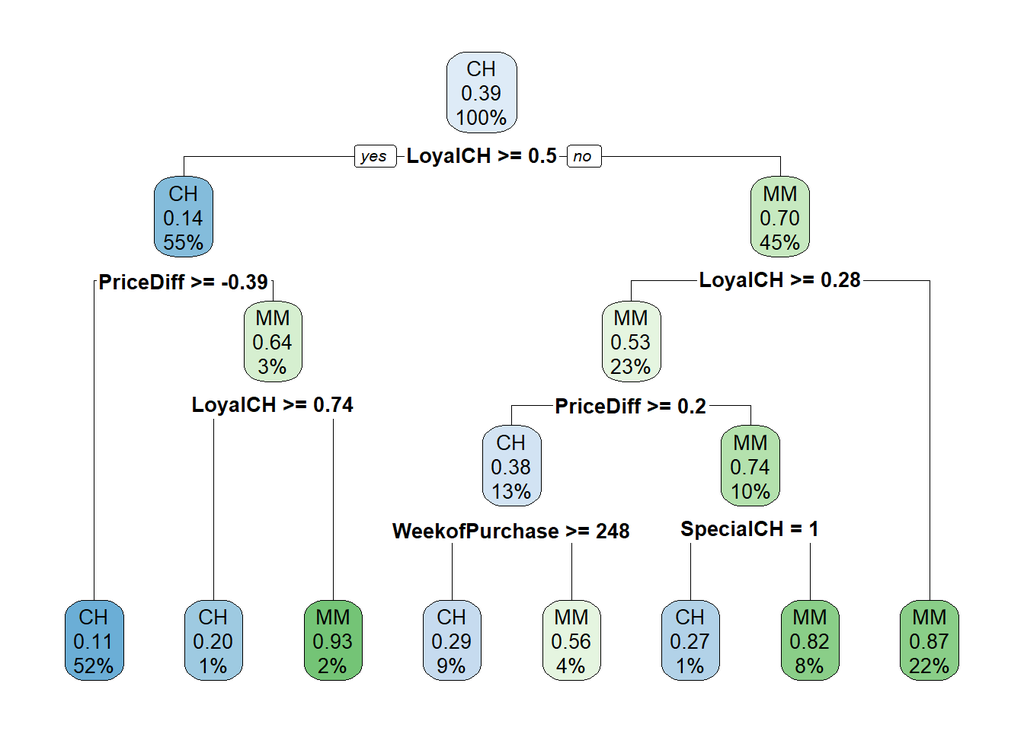

```r
rpart.plot(simple_tree_model[["finalModel"]])
```

### Investigate tree ensemble models: random forest, gradient boosting machine, XGBoost. Try various tuning parameter combinations and select the best model using cross-validation.

## Random Forest

```r
tune_grid <- expand.grid(
  .mtry = c(2, 3, 5, 7, 9, 12, 14),
  .splitrule = "gini",
  .min.node.size = c(5, 10)
)

# random forest
set.seed(1234)
rf_model <- train(Purchase ~ .,
                  method = "ranger",
                  data = data_train,
                  trControl = train_control,
                  tuneGrid = tune_grid,
                  importance = "impurity"
                  )
rf_model
```

```
## Random Forest
##
## 803 samples
##  17 predictor
##   2 classes: 'CH', 'MM'
##
## No pre-processing
## Resampling: Cross-Validated (5 fold, repeated 3 times)
## Summary of sample sizes: 642, 643, 643, 642, 642, 642, ...
## Resampling results across tuning parameters:
##
##   mtry  min.node.size  Accuracy   Kappa
##    2     5             0.8015657  0.5758417
##    2    10             0.8065321  0.5864817
##    3     5             0.8156625  0.6071122
##    3    10             0.8214700  0.6198310
##    5     5             0.8160637  0.6108683
##    5    10             0.8281185  0.6355850
##    7     5             0.8210326  0.6224784
##    7    10             0.8276967  0.6364932
##    9     5             0.8193815  0.6195652
##    9    10             0.8218815  0.6246567
##   12     5             0.8185404  0.6183907
##   12    10             0.8214674  0.6243016
##   14     5             0.8168918  0.6161306
##   14    10             0.8239570  0.6301354
##
## Tuning parameter 'splitrule' was held constant at a value of gini
## Accuracy was used to select the optimal model using the largest value.
## The final values used for the model were mtry = 5, splitrule = gini
##  and min.node.size = 10.
```

## GBM

```r
gbm_grid <- expand.grid(n.trees = c(100, 500, 1000),
                        interaction.depth = c(2, 3, 5),
                        shrinkage = c(0.005, 0.01, 0.1),
                        n.minobsinnode = c(1))
set.seed(1234)
gbm_model <- train(Purchase ~ .,
                   method = "gbm",
                   data = data_train,
                   trControl = train_control,
                   tuneGrid = gbm_grid,
                   verbose = FALSE # gbm by default prints too much output
                   )
gbm_model
```

```
## Stochastic Gradient Boosting
##
## 803 samples
##  17 predictor
##   2 classes: 'CH', 'MM'
##
## No pre-processing
## Resampling: Cross-Validated (5 fold, repeated 3 times)
## Summary of sample sizes: 642, 643, 643, 642, 642, 642, ...
## Resampling results across tuning parameters:
##
##   shrinkage  interaction.depth  n.trees  Accuracy   Kappa
##   0.005      2                   100     0.7849327  0.5196008
##   0.005      2                   500     0.8243815  0.6279735
##   0.005      2                  1000     0.8351708  0.6521180
##   0.005      3                   100     0.7977899  0.5510310
##   0.005      3                   500     0.8314208  0.6431585
##   0.005      3                  1000     0.8389105  0.6603430
##   0.005      5                   100     0.8148266  0.5933683
##   0.005      5                   500     0.8389001  0.6597123
##   0.005      5                  1000     0.8339130  0.6501279
##   0.010      2                   100     0.7948758  0.5590251
##   0.010      2                   500     0.8339286  0.6496545
##   0.010      2                  1000     0.8335067  0.6490127
##   0.010      3                   100     0.8239519  0.6232668
##   0.010      3                   500     0.8384964  0.6599976
##   0.010      3                  1000     0.8301837  0.6427206
##   0.010      5                   100     0.8301837  0.6374693
##   0.010      5                   500     0.8335016  0.6498217
##   0.010      5                  1000     0.8293323  0.6404245
##   0.100      2                   100     0.8268685  0.6340291
##   0.100      2                   500     0.8089984  0.5964427
##   0.100      2                  1000     0.7998680  0.5776145
##   0.100      3                   100     0.8289337  0.6404928
##   0.100      3                   500     0.8114933  0.6012569
##   0.100      3                  1000     0.8036025  0.5847643
##   0.100      5                   100     0.8202148  0.6199749
##   0.100      5                   500     0.8019384  0.5815657
##   0.100      5                  1000     0.8056729  0.5894350
##
## Tuning parameter 'n.minobsinnode' was held constant at a value of 1
## Accuracy was used to select the optimal model using the largest value.
## The final values used for the model were n.trees = 1000, interaction.depth =
##  3, shrinkage = 0.005 and n.minobsinnode = 1.
```

# Refining GBM with values from optimal model

```r
# we can refine the grid around the optimum found
gbm_grid_refined <- expand.grid(
  n.trees = c(500, 1000, 1800),
  interaction.depth = c(2, 3, 5),
  shrinkage = c(0.0025, 0.005, 0.01),
  n.minobsinnode = c(1)
)

set.seed(1234)
gbm_model_refined <- train(Purchase ~ .,
                   method = "gbm",
                   data = data_train,
                   trControl = train_control,
                   tuneGrid = gbm_grid_refined,
                   verbose = FALSE # gbm by default prints too much output
                   )
gbm_model_refined
```

```
## Stochastic Gradient Boosting
##
## 803 samples
##  17 predictor
##   2 classes: 'CH', 'MM'
##
## No pre-processing
## Resampling: Cross-Validated (5 fold, repeated 3 times)
## Summary of sample sizes: 642, 643, 643, 642, 642, 642, ...
## Resampling results across tuning parameters:
##
##   shrinkage  interaction.depth  n.trees  Accuracy   Kappa
##   0.0025     2                   500     0.8027743  0.5769186
##   0.0025     2                  1000     0.8247955  0.6286960
##   0.0025     2                  1800     0.8335119  0.6486934
##   0.0025     3                   500     0.8272774  0.6324353
##   0.0025     3                  1000     0.8314182  0.6434611
##   0.0025     3                  1800     0.8376553  0.6578445
##   0.0025     5                   500     0.8347412  0.6489809
##   0.0025     5                  1000     0.8389053  0.6597960
##   0.0025     5                  1800     0.8343401  0.6509373
##   0.0050     2                   500     0.8256315  0.6307687
##   0.0050     2                  1000     0.8347541  0.6512910
##   0.0050     2                  1800     0.8339182  0.6498559
##   0.0050     3                   500     0.8314208  0.6437302
##   0.0050     3                  1000     0.8384938  0.6593179
##   0.0050     3                  1800     0.8301812  0.6425824
##   0.0050     5                   500     0.8372412  0.6560645
##   0.0050     5                  1000     0.8339182  0.6500768
##   0.0050     5                  1800     0.8260067  0.6327927
##   0.0100     2                   500     0.8347567  0.6510164
##   0.0100     2                  1000     0.8314182  0.6440087
##   0.0100     2                  1800     0.8276863  0.6360630
##   0.0100     3                   500     0.8368323  0.6558407
##   0.0100     3                  1000     0.8318427  0.6460312
##   0.0100     3                  1800     0.8243427  0.6300121
##   0.0100     5                   500     0.8310119  0.6442557
##   0.0100     5                  1000     0.8251837  0.6308604
##   0.0100     5                  1800     0.8181185  0.6164558
##
## Tuning parameter 'n.minobsinnode' was held constant at a value of 1
## Accuracy was used to select the optimal model using the largest value.
## The final values used for the model were n.trees = 1000, interaction.depth =
##  5, shrinkage = 0.0025 and n.minobsinnode = 1.
```

## XGBoost

```r
xgb_grid <- expand.grid(nrounds = c(500, 1000),
                       max_depth = c(2, 3, 5),
                       eta = c(0.01, 0.05),
                       gamma = 0,
                       colsample_bytree = c(0.5, 0.7),
                       min_child_weight = 1, # similar to n.minobsinnode
                       subsample = c(0.5))
set.seed(1234)
xgboost_model <- train(Purchase ~ .,
                       method = "xgbTree",
                       data = data_train,
                       trControl = train_control,
                       tuneGrid = xgb_grid)
xgboost_model
```

```
## eXtreme Gradient Boosting
##
## 803 samples
##  17 predictor
##   2 classes: 'CH', 'MM'
##
## No pre-processing
## Resampling: Cross-Validated (5 fold, repeated 3 times)
## Summary of sample sizes: 642, 643, 643, 642, 642, 642, ...
## Resampling results across tuning parameters:
##
##   eta   max_depth  colsample_bytree  nrounds  Accuracy   Kappa
##   0.01  2          0.5                500     0.8355927  0.6518384
##   0.01  2          0.5               1000     0.8326786  0.6468611
##   0.01  2          0.7                500     0.8372464  0.6567566
##   0.01  2          0.7               1000     0.8330927  0.6485565
##   0.01  3          0.5                500     0.8359964  0.6539733
##   0.01  3          0.5               1000     0.8310093  0.6434491
##   0.01  3          0.7                500     0.8372464  0.6570369
##   0.01  3          0.7               1000     0.8281004  0.6382961
##   0.01  5          0.5                500     0.8306004  0.6420390
##   0.01  5          0.5               1000     0.8247697  0.6299645
##   0.01  5          0.7                500     0.8326734  0.6467556
##   0.01  5          0.7               1000     0.8256030  0.6321357
##   0.05  2          0.5                500     0.8256056  0.6319051
##   0.05  2          0.5               1000     0.8222774  0.6240940
##   0.05  2          0.7                500     0.8239545  0.6288313
##   0.05  2          0.7               1000     0.8123292  0.6027139
##   0.05  3          0.5                500     0.8173059  0.6144234
##   0.05  3          0.5               1000     0.8077381  0.5931676
##   0.05  3          0.7                500     0.8193634  0.6184525
##   0.05  3          0.7               1000     0.8156263  0.6098515
##   0.05  5          0.5                500     0.8106418  0.5995898
##   0.05  5          0.5               1000     0.8098059  0.5976518
##   0.05  5          0.7                500     0.8114803  0.6021988
##   0.05  5          0.7               1000     0.8073266  0.5929998
##
## Tuning parameter 'gamma' was held constant at a value of 0
## Tuning
##  parameter 'min_child_weight' was held constant at a value of 1
##
## Tuning parameter 'subsample' was held constant at a value of 0.5
## Accuracy was used to select the optimal model using the largest value.
## The final values used for the model were nrounds = 500, max_depth = 2, eta
##  = 0.01, gamma = 0, colsample_bytree = 0.7, min_child_weight = 1 and
##  subsample = 0.5.
```

### Compare different models with the resamples function (make sure to set the same seed before model training for all 3 models). Is any of these giving significantly different predictive power than the others?

```r
resamples_object <- resamples(list("rpart" = simple_tree_model,
                                   "rf" = rf_model,
                                   "gbm" = gbm_model_refined,
                                   "xgboost" = xgboost_model))
summary(resamples_object)
```

```
##
## Call:
## summary.resamples(object = resamples_object)
##
## Models: rpart, rf, gbm, xgboost
## Number of resamples: 15
##
## Accuracy
##              Min.   1st Qu.    Median      Mean   3rd Qu.      Max. NA's
## rpart   0.7625000 0.8130823 0.8198758 0.8235766 0.8411102 0.8750000    0
## rf      0.7888199 0.8099767 0.8312500 0.8281185 0.8416149 0.8944099    0
## gbm     0.7937500 0.8198758 0.8437500 0.8389053 0.8571429 0.8819876    0
## xgboost 0.7812500 0.8224379 0.8375000 0.8372464 0.8566964 0.9006211    0
##
## Kappa
##              Min.   1st Qu.    Median      Mean   3rd Qu.      Max. NA's
## rpart   0.4812287 0.6012085 0.6200814 0.6259421 0.6612346 0.7350993    0
## rf      0.5356295 0.6009480 0.6413152 0.6355850 0.6651529 0.7738577    0
## gbm     0.5792158 0.6202990 0.6638655 0.6597960 0.6966519 0.7487062    0
## xgboost 0.5562599 0.6271436 0.6537352 0.6567566 0.6932077 0.7865429    0
```

### Choose the best model and plot ROC curve for the best model on the test set. Calculate and interpret AUC.

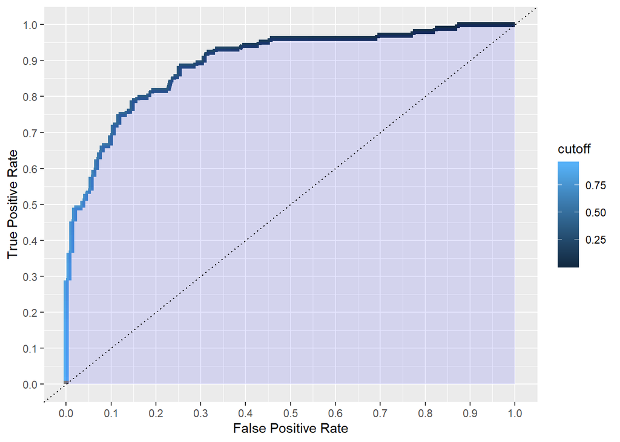

```r
# get probabilities instead of classes
test_prediction_probs <- predict.train(xgboost_model,
                                       newdata = data_test,
                                       type = "prob")

# ROC
xgb_prediction <- prediction(test_prediction_probs$MM,
                              data_test[["Purchase"]])

xgb_perf <- performance(xgb_prediction, measure = "tpr", x.measure = "fpr")

# create df for roc curve
xgb_roc_df <- data.table(
  model = "xgboost",
  FPR = xgb_perf@x.values[[1]],
  TPR = xgb_perf@y.values[[1]],
  cutoff = xgb_perf@alpha.values[[1]]
)

ggplot(xgb_roc_df) +
  geom_line(aes(FPR, TPR, color = cutoff), size = 2) +
  geom_ribbon(aes(FPR, ymin = 0, ymax = TPR), fill = "blue", alpha = 0.1) +
  geom_abline(intercept = 0, slope = 1,  linetype = "dotted", col = "black") +
  scale_y_continuous(limits = c(0, 1), breaks = seq(0, 1, .1)) +
  scale_x_continuous(limits = c(0, 1), breaks = seq(0, 1, .1)) +
  xlab("False Positive Rate") + ylab("True Positive Rate")
```

```r
# AUC
AUC <- performance(xgb_prediction, "auc")@y.values[[1]]
print(AUC)
```

```
## [1] 0.8939948
```

This value tells how much a model is capable of distinguishing between the classes. AUC has a very practical interpretation, it is the probability (89.4%) of correct ranking of a random positive negative pair.

### Inspect variable importance plots for the 3 models. Are similar variables found to be the most important for the 3 models?

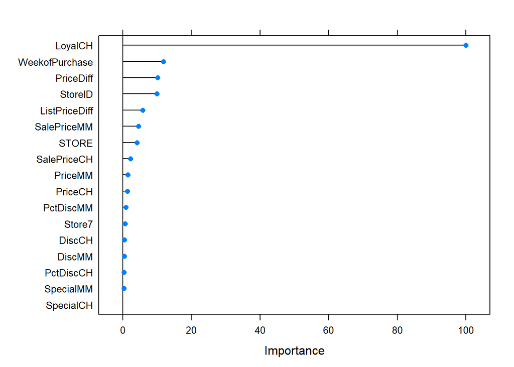

```r
plot(varImp(rf_model))
```

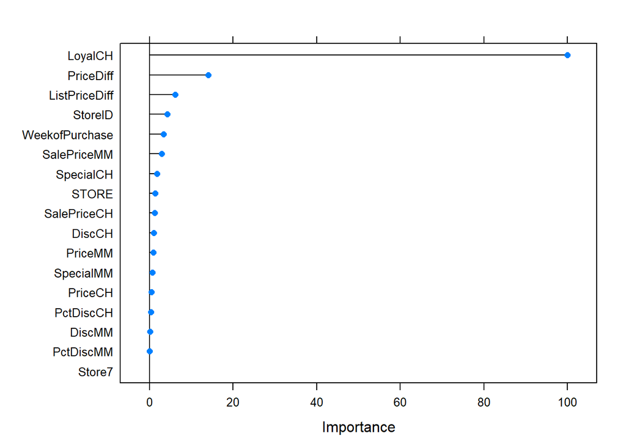

```r
plot(varImp(gbm_model_refined))
```

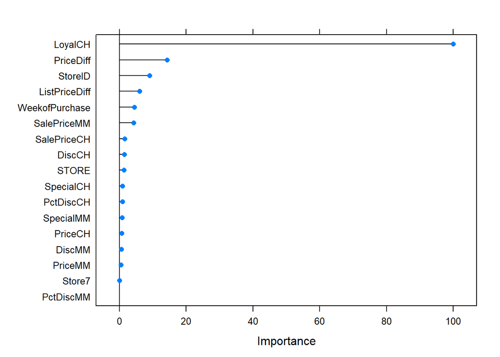

```r
plot(varImp(xgboost_model))
```

Variable importance are pretty similar for the three models. The most important variables are LoyalCH which states if someone is loyal to the CH brand, the PriceDiff, and the StoreID.